# Movie Lens Recommendation System - Project

Komolafe Oyindolapo

2019 M011 12

## Introduction.

This is the capstone project for Data Science. The dataset is Movie lens dataset by Netflix.Netflix uses a recommendation system to predict how many stars a user will give a specific movie. One star suggests it is not a good movie, whereas five stars suggests it is an excellent movie. The challenge is to give basis of how these recommendations are made, motivated by some of the approaches taken by the winners of the Netflix challenges MovieLens 10M movie ratings. This data set contains 10000054 ratings and 95580 tags applied to 10681 movies by 71567 users of the online movie recommender service MovieLens. Users were selected at random for inclusion. All users selected had rated at least 20 movies. No demographic information is included. Each user is represented by an id, and no other information is provided.

## Data Loading and Exploration

This section loads the dataset, partitions the data into test and training set and ensures the data in the test set also appears in the training set. The required libraries are also loaded.

```r
################################
# Create edx set, validation set
################################

# Loading of Data set

if(!require(tidyverse)) install.packages("tidyverse", repos = "http://cran.us.r-project.org")
if(!require(caret)) install.packages("caret", repos = "http://cran.us.r-project.org")
if(!require(data.table)) install.packages("data.table", repos = "http://cran.us.r-project.org")
```

```r
library(dplyr)
library(ggplot2)
library(stringr)
library(gganimate)
library(hrbrthemes)
options(scipen=10000)

# MovieLens 10M dataset:
# https://grouplens.org/datasets/movielens/10m/
# http://files.grouplens.org/datasets/movielens/ml-10m.zip

dl <- tempfile()
download.file("http://files.grouplens.org/datasets/movielens/ml-10m.zip", dl)

ratings <- fread(text = gsub("::", "\t", readLines(unzip(dl, "ml-10M100K/ratings.dat"))),
                 col.names = c("userId", "movieId", "rating", "timestamp"))

movies <- str_split_fixed(readLines(unzip(dl, "ml-10M100K/movies.dat")), "\\::", 3)
colnames(movies) <- c("movieId", "title", "genres")
movies <- as.data.frame(movies) %>% mutate(movieId = as.numeric(levels(movieId))[movieId],
                                           title = as.character(title),
                                           genres = as.character(genres))
movielens <- left_join(ratings, movies, by = "movieId")

# Validation set will be 10% of MovieLens data
set.seed(1, sample.kind="Rounding")
# if using R 3.5 or earlier, use `set.seed(1)` instead
test_index <- createDataPartition(y = movielens$rating, times = 1, p = 0.1, list = FALSE)
edx <- movielens[-test_index,]
temp <- movielens[test_index,]

# Make sure userId and movieId in validation set are also in edx set
validation <- temp %>%
  semi_join(edx, by = "movieId") %>%
  semi_join(edx, by = "userId")

# Add rows removed from validation set back into edx set
removed <- anti_join(temp, validation)
edx <- rbind(edx, removed)

rm(dl, ratings, movies, test_index, temp, movielens, removed)

#Creation 10% of edx for testing of models
edx_index <- createDataPartition(y = edx$rating, times = 1, p = 0.1, list = FALSE)
edx_data <- edx[-edx_index,]
temp <- edx[edx_index,]
edx_val <- temp %>%
  semi_join(edx_data, by = "movieId") %>%
  semi_join(edx_data, by = "userId")

# Add rows removed from edx_val set back into edx_data
removed <- anti_join(temp, edx_val)
edx_data <- rbind(edx_data, removed)

rm(temp, removed, edx_index)
```

## Data Preprocessing and Cleanup

```r
#Separating Year from title
edx <- edx %>% mutate(year = str_extract(title, "(\\d{4})") )
validation <- validation %>% mutate(year = str_extract(title, "(\\d{4})") )

edx_data <- edx_data %>% mutate(year = str_extract(title, "(\\d{4})") )
edx_val <- edx_val %>% mutate(year = str_extract(title, "(\\d{4})") )
```

## Data Vizualization

In this section we attempt to answer the following questions 1. Is it a fair to conclude that genre influences user rating a movie? 2. Has popularity affected user rating?

```r
edx %>% summarize(unique_users = n_distinct(userId), unique_movies = n_distinct(movieId))
```

```
##   unique_users unique_movies
## 1        69878         10677
```

from the result above, we an deduce that not all users rated all movies.

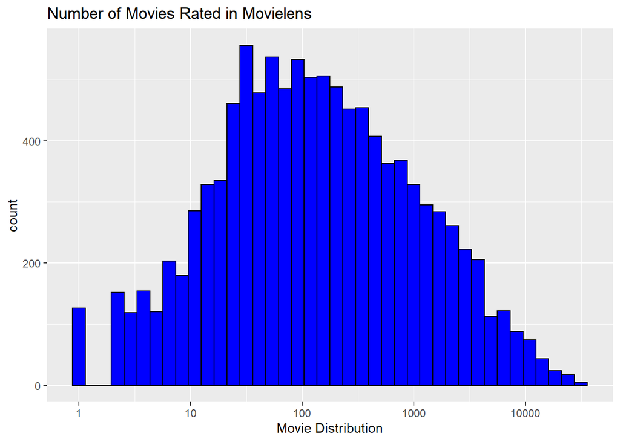

```r
edx %>% group_by(movieId)%>% summarize(count = n()) %>% ggplot(aes(count)) +
              geom_histogram(bins=40,  fill = "blue", col = "black") +
              scale_x_log10() +
              xlab("Movie Distribution") +
              ggtitle("Number of Movies Rated in Movielens")
```

The chart above shows that some movies are rated more than others. We can call such movies blockbusters.

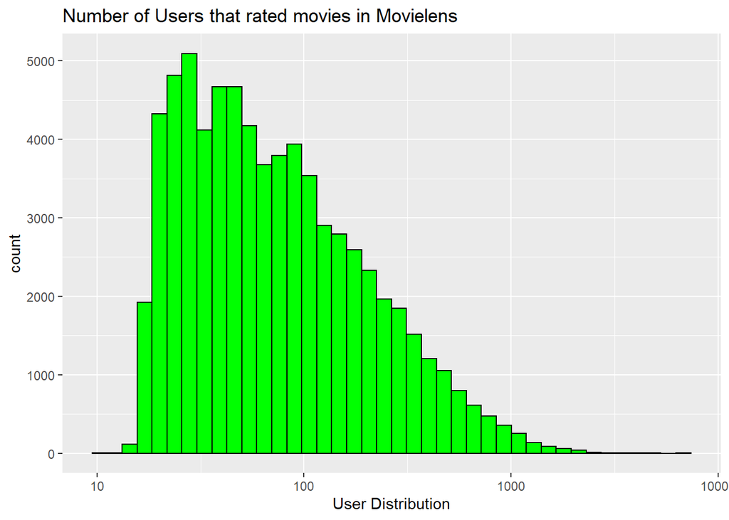

```r
edx %>% group_by(userId)%>% summarize(count = n()) %>% ggplot(aes(count)) +
  geom_histogram(bins=40,  fill = "green", col = "black") +
  scale_x_log10() +
  xlab("User Distribution") +
  ggtitle("Number of Users that rated movies in Movielens")
```

The chart above shows that not all users are active. Some users rate more than others. Comparing this result to the summary of uniques users and movies, it is evident that some users watch the movie without rating.

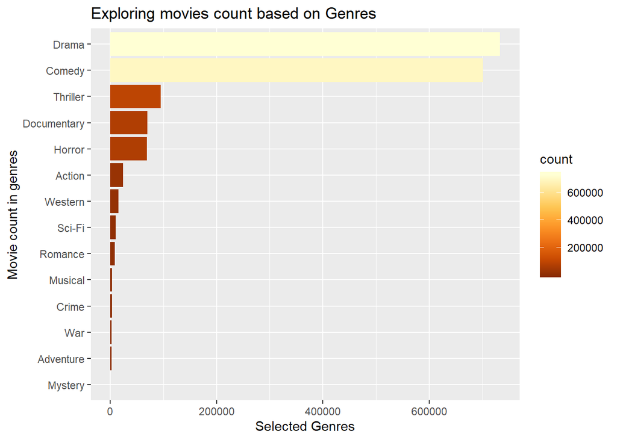

```r
edx  %>% filter(genres %in% c( "War", "Western", "Thriller", "Sci-Fi","Romance", "Mystery", "Musical", "Horror", "  Film-Noir", "Drama", "Documentary","Action", "Crime", "Comedy", "Adventure")) %>%
  group_by(genres) %>% summarise(count = n()) %>%
  mutate(genres = reorder(genres, count)) %>%
  ggplot(aes(genres, count, fill = count)) +
  geom_bar(stat="identity") +
  coord_flip() +
  scale_fill_distiller(palette = "YlOrBr")+
  xlab("Movie count in genres") +
  ylab("Selected Genres") +
  ggtitle("Exploring movies count based on Genres")
```

Next we explore the genre variation in regards to year.

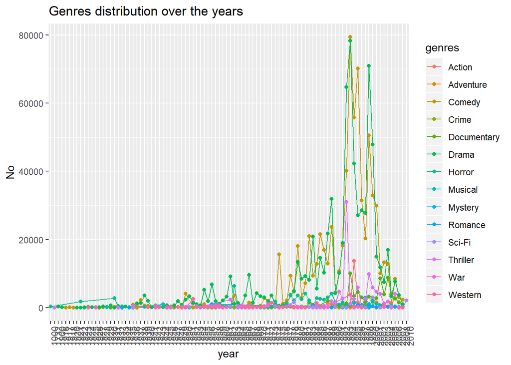

```r
year_info <- edx  %>% filter(genres %in% c( "War", "Western", "Thriller", "Sci-Fi","Romance", "Mystery", "Musical", "Horror", " Film-Noir", "Drama", "Documentary","Action", "Crime", "Comedy", "Adventure")) %>%
                  select(genres, year, rating)
year_info <- year_info %>% group_by(genres, year) %>% summarise(count = n())
year_info %>% ggplot(aes(x = year, y = count, group = genres, color = genres)) +
                              geom_line ()+
                              geom_point() +
  scale_y_continuous() +
  theme(axis.text.x = element_text(angle = 90, hjust = 1)) +
  ggtitle("Genres distribution over the years") +
  ylab("No")
```

From the chart above, we can see that there is a spike in certain genres from 1960. Thus we stream line our data to show only those genres.

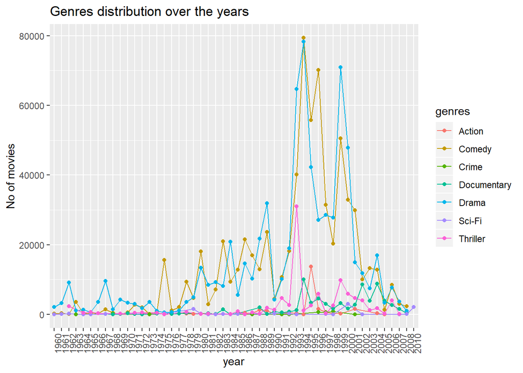

```r
year_info %>% filter(genres %in% c( "Thriller", "Sci-Fi", "Drama", "Documentary","Action", "Crime", "Comedy")) %>%
          filter(year >= 1960) %>% ggplot(aes(x = year, y = count, group = genres, color = genres)) +
          geom_line ()+
          geom_point() +
          scale_y_continuous() +
          theme(axis.text.x = element_text(angle = 90, hjust = 1)) +
          ggtitle("Genres distribution over the years") +
          ylab("No of movies")
```

The chart above shows clearly the year distribution of the genres. In the previous chart, we can see a spike in trend with comedy and Drama. Next we view a chart that explores genres based on movie count

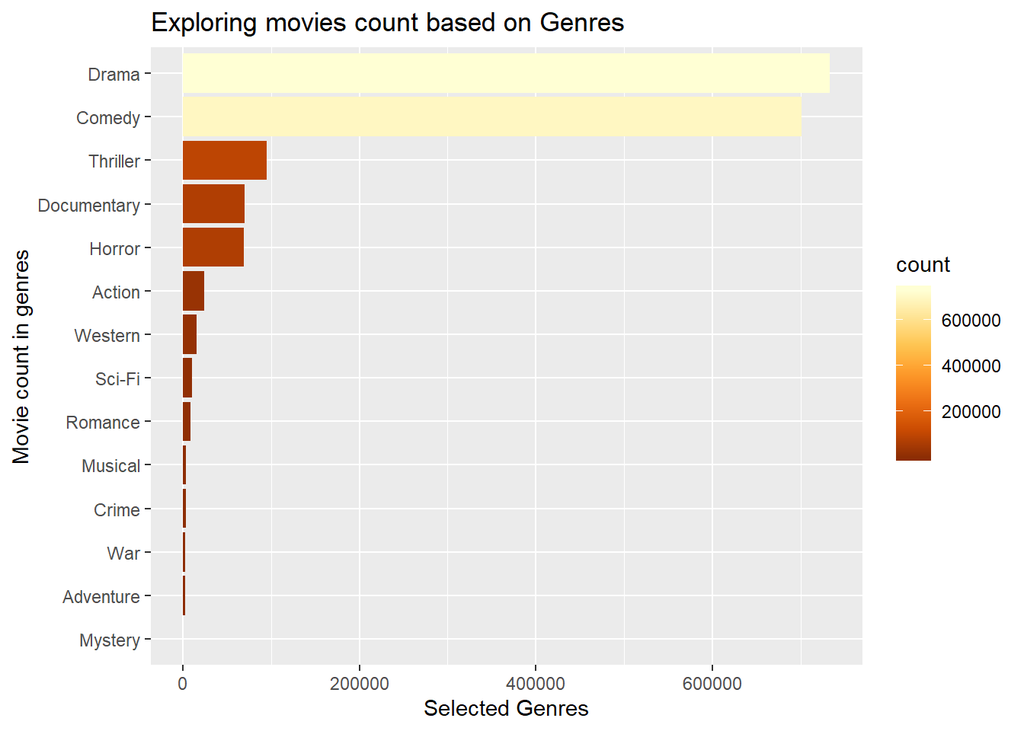

```r
edx  %>% filter(genres %in% c( "War", "Western", "Thriller", "Sci-Fi","Romance", "Mystery", "Musical", "Horror", "  Film-Noir", "Drama", "Documentary","Action", "Crime", "Comedy", "Adventure")) %>%
   group_by(genres) %>% summarise(count = n()) %>%
   mutate(genres = reorder(genres, count)) %>%
  ggplot(aes(genres, count, fill = count)) +
  geom_bar(stat="identity") +
  coord_flip() +
 scale_fill_distiller(palette = "YlOrBr")+
  xlab("Movie count in genres") +
  ylab("Selected Genres") +
  ggtitle("Exploring movies count based on Genres")
```

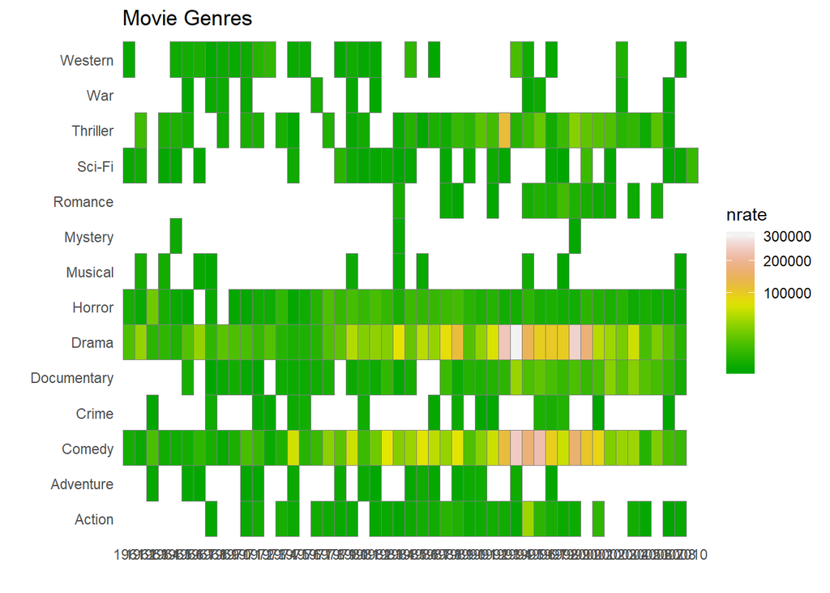

```r
edx %>% group_by(genres, year) %>% summarise(nrate = sum(rating)) %>%
   filter(year > 1960 & genres %in% c( "War", "Western", "Thriller", "Sci-Fi","Romance", "Mystery", "Musical", "Horror", "  Film-Noir", "Drama", "Documentary","Action", "Crime", "Comedy", "Adventure")) %>%
  ggplot(aes(year, genres, fill = nrate)) +
  geom_tile(color = "grey50") +
  scale_fill_gradientn(colors = terrain.colors(1000), trans = "sqrt") +
  geom_vline(xintercept=1963, col = "blue") +
  theme_minimal() + theme(panel.grid = element_blank()) +
  ggtitle("Movie Genres") +
  ylab("") +
  xlab("")
```

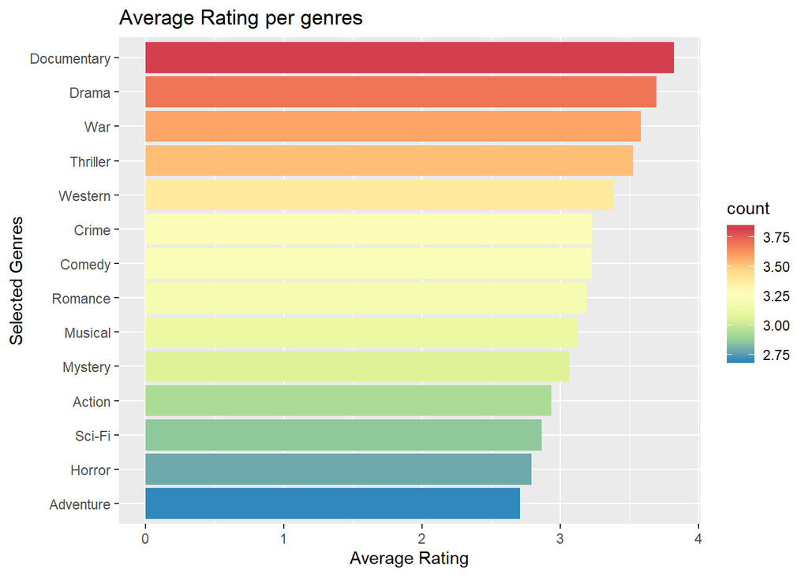

```r
 edx  %>% filter(genres %in% c( "War", "Western", "Thriller", "Sci-Fi","Romance", "Mystery", "Musical", "Horror", " Film-Noir", "Drama", "Documentary","Action", "Crime", "Comedy", "Adventure") & year > 1960) %>%
  group_by(genres) %>% summarise(count = mean(rating)) %>%
  mutate(genres = reorder(genres, count)) %>%
  ggplot(aes(genres, count, fill = count)) +
  geom_bar(stat="identity") +
  coord_flip() +
  scale_fill_distiller(palette = "Spectral")+
  xlab("Selected Genres") +
  ylab("Average Rating") +
  ggtitle("Average Rating per genres")
```

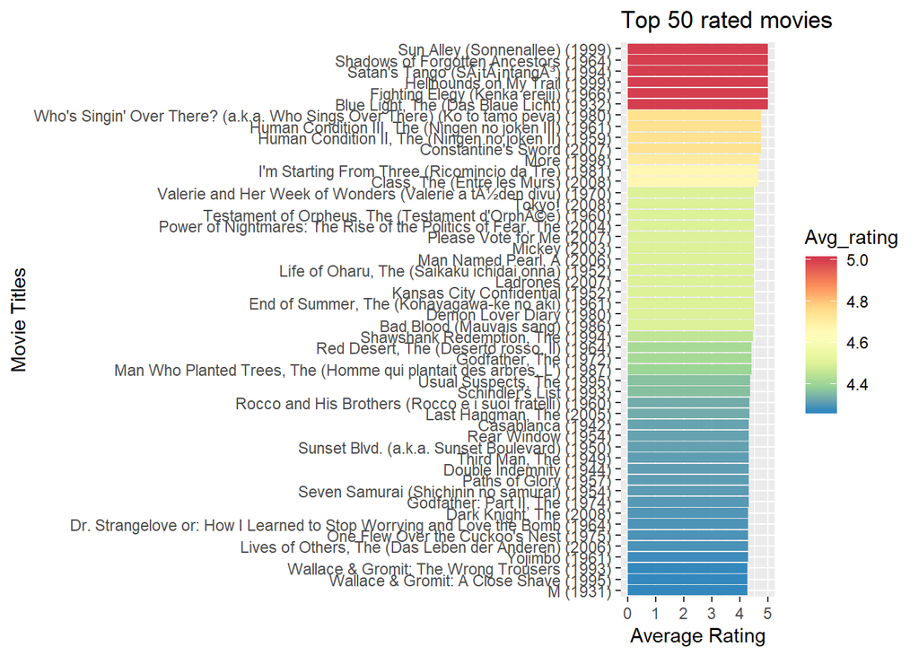

```r
  #To further support the theory, vizualization of movie ratings is required
#Analyzing top rated movie
  edx %>% group_by(title) %>% summarise(Avg_rating = mean(rating)) %>%
    filter(Avg_rating >= 4) %>% arrange(desc(Avg_rating)) %>% top_n(50) %>%
    mutate(title = reorder(title, Avg_rating)) %>%
    ggplot(aes(title, Avg_rating, fill = Avg_rating)) +
    geom_bar(stat="identity") +
    coord_flip() +
    scale_fill_distiller(palette = "Spectral")+
    xlab("Movie Titles") +
    ylab("Average Rating") +
    ggtitle("Top 50 rated movies")
```

Using the Avg_rating per movie to determine the Top rated movie we will see that Sun Alley, Shadows of forgotten ANcestors etc are rated high. Is this really the case? Next we explore the Top rated movies using average rating and Number of rating

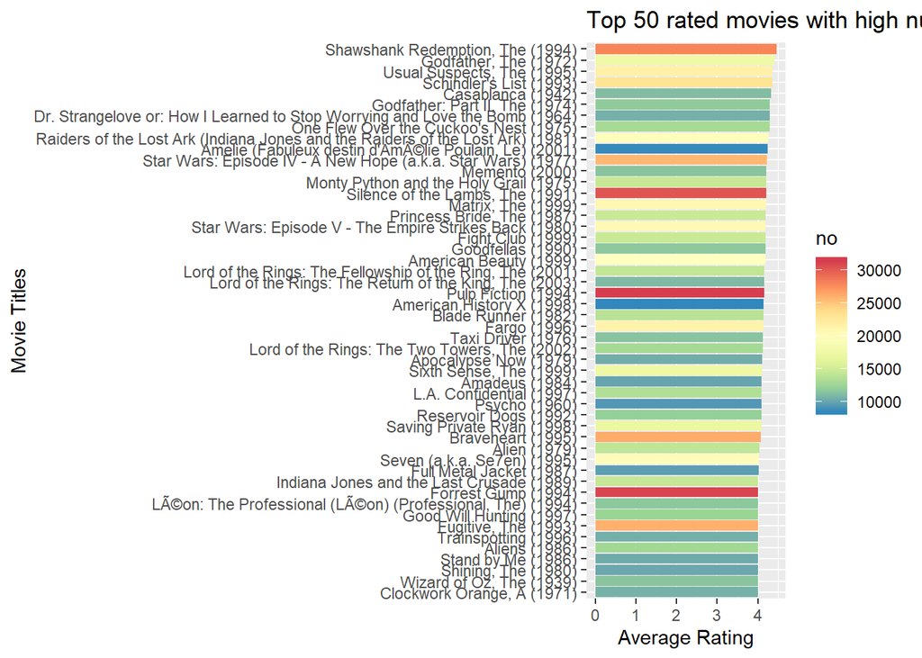

```r
edx %>% group_by(title) %>% summarise(Avg_rating = mean(rating), no = n()) %>%
    filter(Avg_rating >= 4) %>% arrange(desc(no, Avg_rating)) %>% top_n(50) %>%
    mutate(title = reorder(title,Avg_rating)) %>%
    ggplot(aes(title, Avg_rating, fill = no)) +
    geom_bar(stat="identity") +
    coord_flip() +
    scale_fill_distiller(palette = "Spectral")+
    xlab("Movie Titles") +
    ylab("Average Rating") +
    ggtitle("Top 50 rated movies with high number of ratings")
```

Here, we can see that Shawshank Redemption (1994) has the highest Avg rating, though Pulp fiction (1994) has the highest rating.

In conclusion, a movie genre influences the popularity and popularity has also drives movie rating.

## Data Modelling

In Machine Learning, RMSE is an approach use to define best. RMSE in the Netflix challenge can be assumed to be the typical error made when predicting a movie rating. Thus RMSE function can be written as –

```r
RMSE <- function(true_ratings, predicted_ratings){
  sqrt(mean((true_ratings - predicted_ratings)^2))
}
```

To build the model edx_data and edx_val will be used to train and test respectively

## Guessing Model

The first model is Using Guessing Algorithm to estimate movie rating

```r
#Calculate average of all ratings. This means predicting the same rating for the movie regardless of the user, length or year of movie
Average_rating <- mean(edx_data$rating)
#Calculating RMSE based on average
avg_rmse <- RMSE(edx_val$rating, Average_rating)
```

## Movie Effect

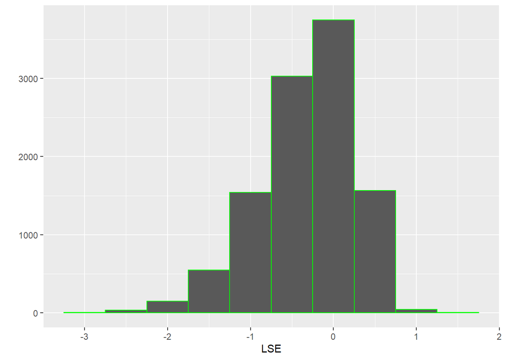

```r
#understand how the movieId affects ratings
movie_average <- edx_data %>% group_by(movieId) %>% summarize(LSE = mean(rating - Average_rating))
#plotting the movie average to see the result
movie_average %>% qplot(LSE, geom ="histogram", bins = 10, data = ., color = I("green"))
```

```r
#calculating predicted rating which is mean + bias
movie_effect_pred <- Average_rating + edx_val %>% left_join(movie_average, by="movieId") %>% pull(LSE)
movie_effect_rmse <- RMSE(movie_effect_pred, edx_val$rating)

movie_effect_rmse
```

```
## [1] 0.9441568
```

## User effect

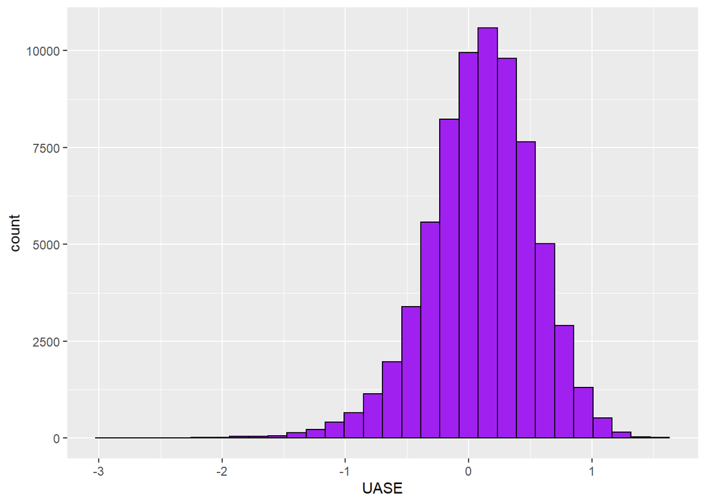

```r
user_average = edx_data %>% group_by(userId) %>% summarize(UASE = mean(rating - Average_rating))

user_average %>% ggplot(aes(UASE)) +  geom_histogram(bins = 30, color = "black", fill = "purple")
```

```r
user_effect_pred <- Average_rating + edx_val %>% left_join(user_average, by="userId") %>% pull(UASE)
user_effect_rmse <- RMSE(user_effect_pred, edx_val$rating)

user_effect_rmse
```

```
## [1] 0.9795916
```

### Year effect

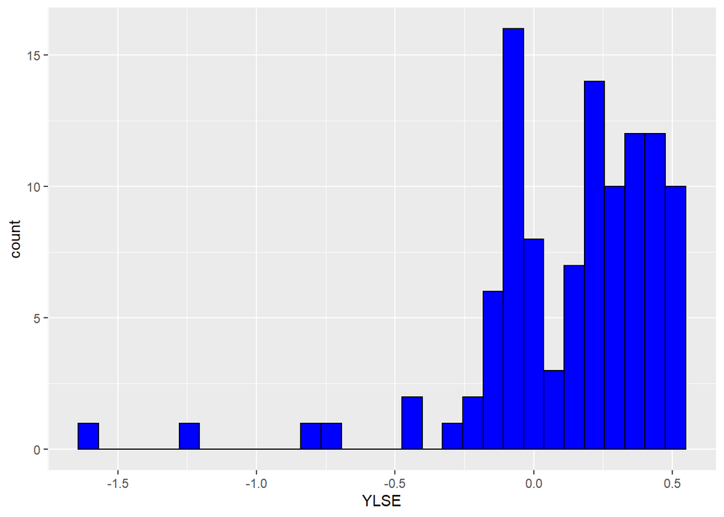

```r
year_average = edx_data %>% group_by(year) %>% summarise(YLSE = mean(rating - Average_rating))
year_average %>% ggplot(aes(YLSE)) +  geom_histogram(bins = 30, color = "black", fill = "blue")
```

```r
year_effect_pred <- Average_rating + edx_val %>% left_join(year_average, by="year") %>% pull(YLSE)
year_effect_rmse <- RMSE(year_effect_pred, edx_val$rating)

year_effect_rmse
```

```
## [1] 1.050134
```

### User effect and Movie effect

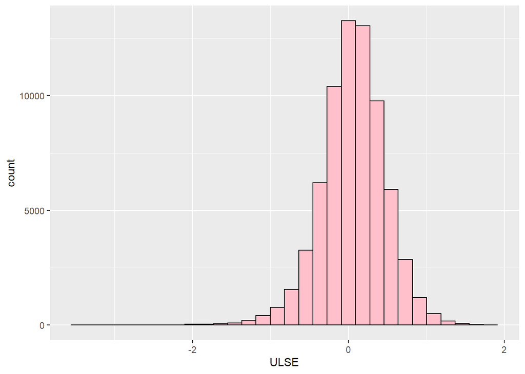

```r
userMovie_average <- edx_data %>% left_join(movie_average, by="movieId") %>% group_by(userId) %>%
                  summarize(ULSE = mean(rating - Average_rating - LSE))
userMovie_average %>% ggplot(aes(ULSE)) +  geom_histogram(bins = 30, color = "black", fill = "pink")
```

```r
userMovie_effect_pred <- edx_val %>%
                    left_join(movie_average, by ="movieId") %>%
                    left_join(userMovie_average, by="userId") %>%
                    mutate(predicted = Average_rating + LSE + ULSE) %>% pull(predicted)


userMovie_effect_rmse <- RMSE(userMovie_effect_pred, edx_val$rating)

userMovie_effect_rmse
```

```
## [1] 0.8659736
```

### Year, User and Movie Effect

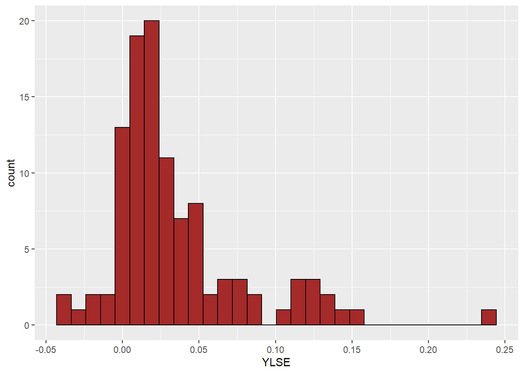

```r
YuserMovie_average <- edx_data %>%
    left_join(movie_average, by="movieId") %>%
    left_join (userMovie_average, by="userId") %>%
    group_by( year) %>%
  summarize(YLSE = mean(rating - Average_rating - LSE - ULSE))
YuserMovie_average %>% ggplot(aes(YLSE)) +  geom_histogram(bins = 30, color = "black", fill = "brown")
```

```r
YuserMovie_effect_pred <- edx_val %>%
  left_join(movie_average, by ="movieId") %>%
  left_join(userMovie_average, by="userId") %>%
  left_join(year_average, by="year") %>%
  mutate(predicted = Average_rating + LSE + ULSE + YLSE) %>% pull(predicted)


YuserMovie_effect_rmse <- RMSE(YuserMovie_effect_pred, edx_val$rating)

YuserMovie_effect_rmse
```

```
## [1] 0.877569
```

### Genres, Movie, User and Year effect

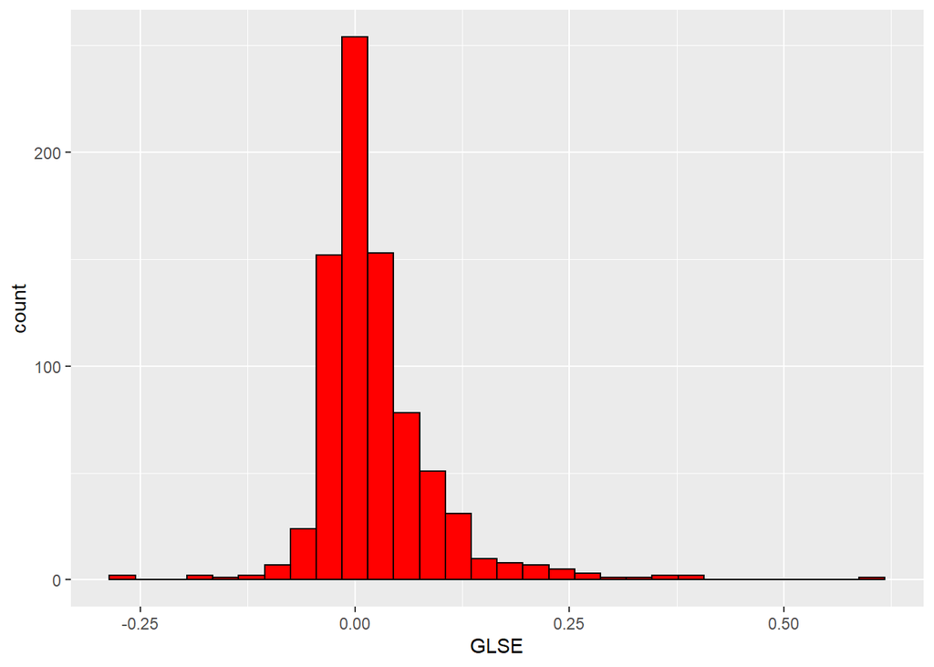

```r
GenresMovie_avarage <- edx_data %>%
  left_join(movie_average, by="movieId") %>%
  left_join (userMovie_average, by="userId") %>%
  left_join(YuserMovie_average, by="year") %>%
  group_by(genres) %>%
  summarize(GLSE = mean(rating- Average_rating - LSE- ULSE - YLSE))
GenresMovie_avarage %>% ggplot(aes(GLSE)) +  geom_histogram(bins = 30, color = "black", fill = "red")
```

```r
GenresM_movies_pred <- edx_val %>%
  left_join(movie_average, by="movieId") %>%
  left_join (userMovie_average, by="userId") %>%
  left_join(YuserMovie_average, by="year") %>%
  left_join(GenresMovie_avarage, by ="genres") %>%
  mutate(predicted = Average_rating + LSE +ULSE +YLSE +GLSE) %>% pull(predicted)
GuserMovie_effect_rmse <- RMSE(GenresM_movies_pred, edx_val$rating)

GuserMovie_effect_rmse
```

```
## [1] 0.8653178
```

## Regularization

From the charts and previous analysis of top rated movies, we wil notice that some of the best rated movies are rated by few users. Thus the need to remove noise

```r
##selecting the tuning parameter lamda for cross validation on edx dataset
lambdas <- seq(0, 5, 0.25)
```

### Regularized Movie Effect

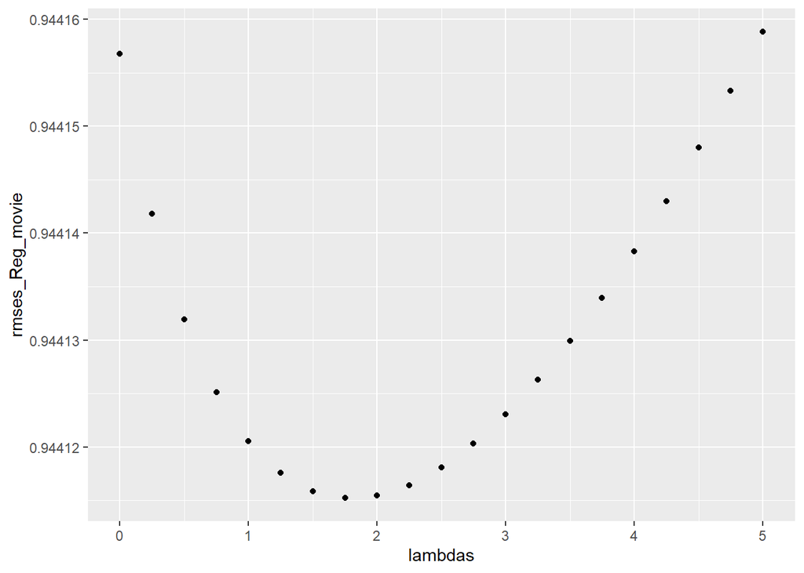

```r
Reg_movie <- edx_data %>%
  group_by(movieId) %>%
  summarize(b_i = sum(rating - Average_rating), n_i = n())

rmses_Reg_movie <- sapply(lambdas, function(l){
  predicted_ratings <- edx_val %>%
    left_join(Reg_movie, by='movieId') %>%
    mutate(b_u = b_i/(n_i+l)) %>%
    mutate(pred = Average_rating + b_u) %>%
    pull(pred)
  return(RMSE(predicted_ratings, edx_val$rating))
})
qplot(lambdas, rmses_Reg_movie)
```

```r
#Minimum lamda
lambdas[which.min(rmses_Reg_movie)]
```

```
## [1] 1.75
```

```r
#RMSE for the model
min(rmses_Reg_movie)
```

```
## [1] 0.9441152
```

### Regularized Movie and User Effect

```r
#Regularized Movie and User Effect
rmses_Reg_movie_user <- sapply(lambdas, function(l)
  {


  b_i <- edx_data %>%
    group_by(movieId) %>%
    summarize(b_i = sum(rating - Average_rating)/(n()+l))
  b_u <- edx_data %>%
    left_join(b_i, by="movieId") %>%
    group_by(userId) %>%
    summarize(b_u = sum(rating - b_i - Average_rating)/(n()+l))
  predicted_ratings <-
    edx_val %>%
    left_join(b_i, by = "movieId") %>%
    left_join(b_u, by = "userId") %>%
    mutate(pred = Average_rating + b_i + b_u) %>%
    pull(pred)
  return(RMSE(predicted_ratings, edx_val$rating))
})
```

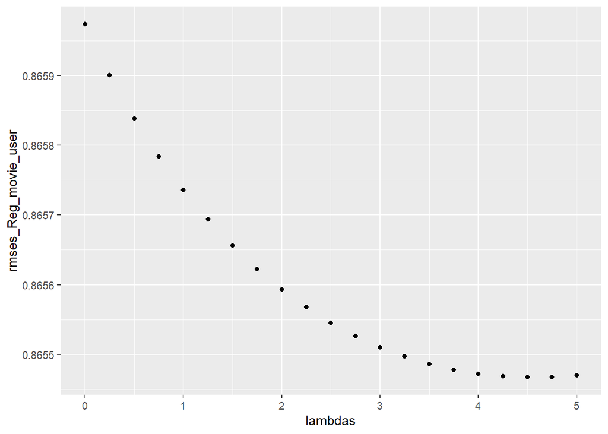

```r
qplot(lambdas, rmses_Reg_movie_user)
```

```r
lambda <- lambdas[which.min(rmses_Reg_movie_user)]
lambda
```

```
## [1] 4.5
```

```r
#RMSE for the model
min(rmses_Reg_movie_user)
```

```
## [1] 0.8654673
```

### Creating a table to aggregate all RMSE Models of Dataset edx

```r
#creating a table to aggregate all RMSE Models of Dataset edx
rmse_results <- tibble(method = "Using the average", RMSE = avg_rmse)
rmse_results <- bind_rows(rmse_results, tibble(method = "The movie effect", RMSE = movie_effect_rmse))
rmse_results <- bind_rows(rmse_results, tibble(method = "The User effect", RMSE = user_effect_rmse))
rmse_results <- bind_rows(rmse_results, tibble(method = "The Year effect", RMSE = year_effect_rmse))
rmse_results <- bind_rows(rmse_results, tibble(method ="The user + Movie Effect Model", RMSE = userMovie_effect_rmse))
rmse_results <- bind_rows(rmse_results, tibble(method ="The user + Movie + Year Effect Model ", RMSE = YuserMovie_effect_rmse))
rmse_results <- bind_rows(rmse_results, tibble(method ="The user + Movie + Year + Genres Effect Model ", RMSE = GuserMovie_effect_rmse))
rmse_results <- bind_rows(rmse_results, tibble(method ="Regularized Movie Effect", RMSE = min(rmses_Reg_movie)))
rmse_results <- bind_rows(rmse_results, tibble(method ="Regularized Movie + User Effect", RMSE = min(rmses_Reg_movie_user)))

rmse_results %>% knitr::kable()
```

| method | RMSE |
| --- | --- |
| Using the average | 1.0611350 |
| The movie effect | 0.9441568 |
| The User effect | 0.9795916 |
| The Year effect | 1.0501344 |
| The user + Movie Effect Model | 0.8659736 |
| The user + Movie + Year Effect Model | 0.8775690 |
| The user + Movie + Year + Genres Effect Model | 0.8653178 |
| Regularized Movie Effect | 0.9441152 |
| Regularized Movie + User Effect | 0.8654673 |

## Validation of selected Model

```r
l <- lambdas[which.min(rmses_Reg_movie_user)]

mu <- mean(validation$rating)

b_i <- validation %>%
  group_by(movieId) %>%
  summarize(b_i = sum(rating - mu)/(n()+l))
b_u <- validation %>%
  left_join(b_i, by="movieId") %>%
  group_by(userId) %>%
  summarize(b_u = sum(rating - b_i - mu)/(n()+l))
predicted_ratings <-
  validation %>%
  left_join(b_i, by = "movieId") %>%
  left_join(b_u, by = "userId") %>%
  mutate(pred = mu + b_i + b_u) %>%
  pull(pred)

RMSE(predicted_ratings, validation$rating)
```

```
## [1] 0.8388471
```

```r
# The RMSE of the model using validated dataset is
RMSE(predicted_ratings, validation$rating)
```

```
## [1] 0.8388471
```

```r
RMSE(predicted_ratings, validation$rating)
```

```
## [1] 0.8388471
```